# Practical Machine Learning Project

Tony Lew

2015-09-26

# Executive Summary

This is a random forest model used to predict the quality of activity and the out of sample error for my model is 0.26% (see Figure 1 - ErrorRate Plot). The quality of activity is classified as one of the following: A B C D E where class A corresponds to the specified execution of the exercise, while the other 4 classes correspond to common mistakes.

With a classification ranging from A to E (classe variable), I chose random forests as my model algorithm. Though there are many advantages to random forests, my motivating reasons are:

It does not overfit. It can run as many trees as you want. It is fast. It is unexcelled in accuracy among current algorithms. It runs efficiently on large data bases. It can handle thousands of input variables without variable deletion. It gives estimates of what variables are important in the classification. It generates an internal unbiased estimate of the generalization error as the forest building progresses. It estimates cross validation internally, during the run.

Special recognition goes to the following group who has made this dataset available from this website:

http://groupware.les.inf.puc-rio.br/har

Ugulino, W.; Cardador, D.; Vega, K.; Velloso, E.; Milidiu, R.; Fuks, H. Wearable Computing: Accelerometers’ Data Classification of Body Postures and Movements. Proceedings of 21st Brazilian Symposium on Artificial Intelligence. Advances in Artificial Intelligence - SBIA 2012. In: Lecture Notes in Computer Science. , pp. 52-61. Curitiba, PR: Springer Berlin / Heidelberg, 2012. ISBN 978-3-642-34458-9. DOI: 10.1007/978-3-642-34459-6_6.

Read more: http://groupware.les.inf.puc-rio.br/har#dataset#ixzz3jexdk0ml

# R Setup

The libraries that must be loaded are here:

```r
  library(randomForest)
  library(lattice);
  library(ggplot2);
  library(sqldf);
```

# Exploratory Data Analysis

```r
filedir <- "E:/Coursera/PracticalMachineLearningProject/"
trainfile <- paste(filedir, "pml-training.csv", sep="")
train <- data.frame(read.csv(trainfile))
testfile <- paste(filedir, "pml-testing.csv", sep="")
test <- data.frame(read.csv(testfile))
```

Looking at the data, the first several variables are unrelated to the testing we seek. They are used as classification variables with X simply being a row identification variable since they are not computable variables as measurements are.

Specifically, they are:

X user_name raw_timestamp_part_1 raw_timestamp_part_2 cvtd_timestamp new_window num_window

Also, a number of columns are mostly null or empty (about 98% of the time) which we should omit as well. Since this revolves around the column new_window I was able to calculate this statistic.

```r
sqldf("
      select
                x.new_window as emptycolumn,
                COUNT(1) as total
      from      train x
      group by  x.new_window
      ")
```

```
##   emptycolumn total
## 1          no 19216
## 2         yes   406
```

I have extracted the column names from our test data set to use for creating the subset of data. So a new subset of the original dataset has been created to omit these classification variables along with the empty columns from both the training and testing sets.

```r
trainsubset   <- sqldf("
                        select
                                  roll_belt,pitch_belt,yaw_belt,total_accel_belt,
                                  gyros_belt_x,gyros_belt_y,gyros_belt_z,
                                  accel_belt_x,accel_belt_y,accel_belt_z,
                                  magnet_belt_x,magnet_belt_y,magnet_belt_z,
                                  roll_arm,pitch_arm,yaw_arm,total_accel_arm,
                                  gyros_arm_x,gyros_arm_y,gyros_arm_z,
                                  accel_arm_x,accel_arm_y,accel_arm_z,
                                  magnet_arm_x,magnet_arm_y,magnet_arm_z,
                                  roll_dumbbell,pitch_dumbbell,yaw_dumbbell,
                                  gyros_dumbbell_x,gyros_dumbbell_y,gyros_dumbbell_z,
                                  accel_dumbbell_x,accel_dumbbell_y,accel_dumbbell_z,
                                  magnet_dumbbell_x,magnet_dumbbell_y,magnet_dumbbell_z,
                                  roll_forearm,pitch_forearm,yaw_forearm,total_accel_forearm,
                                  gyros_forearm_x,gyros_forearm_y,gyros_forearm_z,
                                  accel_forearm_x,accel_forearm_y,accel_forearm_z,
                                  magnet_forearm_x,magnet_forearm_y,magnet_forearm_z,
                                  classe
                        from      train x
                        where     new_window = 'no'
                      ")


testsubset   <- sqldf("
                        select
                                  roll_belt,pitch_belt,yaw_belt,total_accel_belt,
                                  gyros_belt_x,gyros_belt_y,gyros_belt_z,
                                  accel_belt_x,accel_belt_y,accel_belt_z,
                                  magnet_belt_x,magnet_belt_y,magnet_belt_z,
                                  roll_arm,pitch_arm,yaw_arm,total_accel_arm,
                                  gyros_arm_x,gyros_arm_y,gyros_arm_z,
                                  accel_arm_x,accel_arm_y,accel_arm_z,
                                  magnet_arm_x,magnet_arm_y,magnet_arm_z,
                                  roll_dumbbell,pitch_dumbbell,yaw_dumbbell,
                                  gyros_dumbbell_x,gyros_dumbbell_y,gyros_dumbbell_z,
                                  accel_dumbbell_x,accel_dumbbell_y,accel_dumbbell_z,
                                  magnet_dumbbell_x,magnet_dumbbell_y,magnet_dumbbell_z,
                                  roll_forearm,pitch_forearm,yaw_forearm,total_accel_forearm,
                                  gyros_forearm_x,gyros_forearm_y,gyros_forearm_z,
                                  accel_forearm_x,accel_forearm_y,accel_forearm_z,
                                  magnet_forearm_x,magnet_forearm_y,magnet_forearm_z,
                                  problem_id
                        from      test x
                        where     new_window = 'no'
                      ")
```

# Regression Modeling Analysis

So here is my prediction for the problem ids in the test data set.

```r
RFModel <- randomForest(formula=classe ~ .,
                         data=trainsubset, na.action=na.omit, family='gaussian')
RFPredict <- predict(RFModel, newdata=testsubset, type="response")
RFPredict
```

```
##  1  2  3  4  5  6  7  8  9 10 11 12 13 14 15 16 17 18 19 20
##  B  A  B  A  A  E  D  B  A  A  B  C  B  A  E  E  A  B  B  B
## Levels: A B C D E
```

# Cross Validation

As for cross validation, in random forests, there is no need for cross-validation or a separate test set to get an unbiased estimate of the test set error. It is estimated internally , during the run.

# Figures

### Figure 1 - ErrorRate Plot

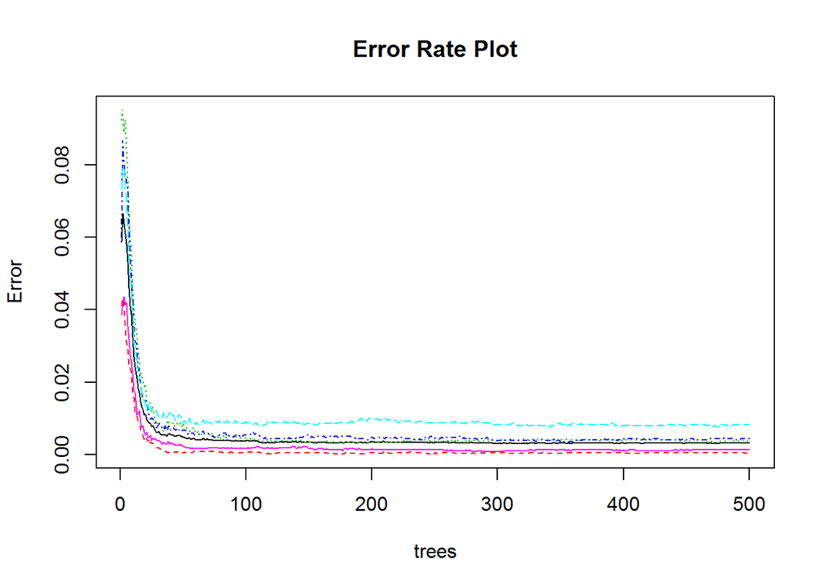

```r
plot(RFModel, main='Error Rate Plot')
```